# A Deep-DiD Method to Estimate Heterogeneous Treatment Effects: Application to Content Creator Selection

Converted from PDF `Cheng-DeepDiDHeterogeneousEffects-2026-MKSC.pdf` · 23 pages · anchors: page `#pN`, block `#pN-bK`

Page 1

### **A Deep-DiD Method to Estimate Heterogeneous Treatment Effects: Application to Content Creator Selection**

#### **Yan Cheng,<sup>a,</sup>* Jingbo Wang,<sup>b,</sup>* Xinyu Cao,<sup>b,</sup>* Zuo-Jun Max Shen,<sup>c</sup>Yuhui Zhang<sup>d</sup>**

[figure not shown]

NOTE: complex table shown as an image of the PDF; the text below is a rough machine extraction and may be mis-aligned.

**extracted text (unreliable layout)**

**1. Introduction** Difference-in-Difference (DiD) is a commonly used method to estimate the average treatment effect on the treated in a quasi-experimental setting, with the key identifying assumption that the average outcome in the treated and control groups would have fol lowed parallel trends in the absence of treatment (Roth et al. 2023). However, this estimate only allows us to understand whether and by how much an inter vention is effective on average. The explosion of data now makes it possible to explore how treatment effects vary across individuals with different charac teristics. By understanding how individuals respond to interventions differently, companies can customize their interventions to maximize effectiveness. Thus, estimating heterogeneous treatment effects (HTEs) can significantly enhance various marketing practices,

such as pricing strategies, product recommendations, and marketing campaign optimization (see, e.g., Fong et al. 2015, Ascarza 2018, and Hitsch et al. 2024).

Although the availability of rich data allows for high-dimensional pretreatment features, estimating HTEs parametrically becomes more challenging because there can be complex interactions between pretreatment features, and it is difficult to assume a correct functional relationship between HTEs and pre treatment features. Existing works have proposed sev eral nonparametric approaches for the estimation of HTEs, including Bayesian nonparametric methods (see, e.g., Hill 2011) and tree-based methods (see, e.g., Wager and Athey 2018).

Farrell et al. (2021) demonstrated the use of DNN for estimating causal parameters, and Farrell et al. (2020) presented a DNN-based framework that can

258

**MARKETING SCIENCE Vol. 45, No. 2, March–April 2026, pp. 258–279 ISSN 0732-2399 (print), ISSN 1526-548X (online) https://pubsonline.informs.org/journal/mksc**

Page 2

estimate fully flexible nonparametric individual het erogeneity. Inspired by these works, we integrate deep neural networks (DNN) in a DiD framework to estimate HTEs. We propose a dual-network archi tecture consisting of two DNN structures. One DNN structure captures the nonparametric relationship between the treatment effect β(·) and pretreatment fea tures **W***i*. The other DNN structure summarizes high- dimensional individual fixed effects *µi* and time fixed effects τ*t* into a nuisance function *f*(*µi*,τ*t*), which also allows for possible interactions between them. The combination of these two parts forms a semipara metric DiD model with DNNs embedded. We name it the *Deep-DiD* model.

Through simulations, we demonstrate that our Deep- DiD method can uncover the true HTEs with high accuracy across various functional forms of the true β(·) and *f*(·,·). We also show that the embedded DNN structures demonstrate more robust estimation perfor mance than linear estimators and random forests. We further examine how the estimation performance of our approach varies with sample sizes, feature dimen sions, and different implementation choices. Overall, our Deep-DiD method demonstrates high accuracy and robustness in estimation.

We apply our method to an empirical setting in which a large video-sharing platform launched a “Creator Signing Program” (“the signing program” hereafter) aimed at identifying promising creators and encouraging them to produce more high-quality con tent. The program was initially launched in three countries located in South America, Africa, and Europe.<sup>1</sup> Signed creators received monthly payments based on their performance. We apply our method to estimate the HTEs of the signing program and further demonstrate how our estimation can aid the platform in optimizing creator selection.

We construct a matched data set with 2,343 creators who were signed from May 1–June 30, 2022 (the trea ted group) and 2,343 creators who remained unsigned (the control group). For each creator, we observed their activities in the 89 days before and 90 days after the signing date.<sup>2</sup> We define two performance mea sures: the total user viewing time contributed by the creator’s videos and the total user engagement con tributed by the creators’ videos. The two groups show parallel trends in daily average performance measures before treatment. Using a canonical DiD model, we show that the signing program substantially boosts the performance metrics of signed creators.

We further prepare the data for estimating the Deep-DiD model and testing its performance in crea tor selection. We construct a set of variables (**W***i*) that describe creators’ pretreatment characteristics in three aspects: Creator Production and Viewer Responses, Visual Features, and Audio Features. Because of the

loss of some video data, the data set with the full set of pretreatment features contains 2,204 creators, with 1,126 from the treated group and 1,078 from the con trol group. We randomly split this data set into two parts: 60% (1,322 creators) for model training and validation and 40% (882 creators) for out-of-sample testing. The trained model provides an estimated function <sup>ˆ</sup>β(·), which we can apply to calculate <sup>ˆ</sup>β*i*

ˆβ(**W***i*) for each *i* in both the training-validation and test sets. The estimated treatment effects reveal sub stantial heterogeneity across creators.

Our method can help the platform optimize creator selection. By utilizing our estimated function β(**W***i*) and each creator’s pretreatment features **W***i*, the plat form can estimate how much the signing program will change the performance of each creator. The plat form can then select the creators with the highest esti mated treatment effects to sign.

We evaluate this creator selection method through out-of-sample tests. Among the 882 creators in the test set, 441 were signed by the platform (labeled “Platform Selected”). We also select 441 creators with the highest estimated treatment effects (labeled “Model Selected”) and compare them with the Platform Selected ones. The Model Selected creators show signifi cantly higher estimated treatment effects compared with the Platform Selected creators. Furthermore, among creators signed by the platform, those selected by the model demonstrate substantially higher actual perfor mance jumps compared with those not selected by the model. Here, a creator’s performance jump is defined as his or her daily average performance after the signing date minus that before the signing date. This measure can be considered an “empirically observed” treatment effect of the signing program on signed creators, although it is not strictly causal. These two evaluation results collectively demonstrate that creator selection based on our Deep-DiD method outperforms the plat form’s selection. We also show that creator selection based on our Deep-DiD method consistently performs better than selection based on linear models.

**1.1. Contributions to Literature** Methodologically, our paper contributes to the liter ature on machine-learning-based causal inference. Machine-learning-based causal inference methods are advancing rapidly, driven by the availability of big data and powerful computing platforms. These advancements enable researchers and practitioners to examine new empirical scenarios that go beyond the capabilities of traditional methods. For instance, they allow for the handling of high-dimensional covariates (Belloni et al. 2017) and the estimation of heteroge neous treatment effects for optimal targeting (Hitsch et al. 2024). Wager and Athey (2018) proposed to estimate heterogeneous treatment effects using

**Cheng et al.:** *A Deep-DiD Method to Estimate Heterogeneous Treatment Effects* Marketing Science, 2026, vol. 45, no. 2, pp. 258–279, © 2026 INFORMS 259

Page 3

random forests. Applying this method, Guo et al. (2021) estimated the heterogeneous treatment effects of the Physician Payment Sunshine Act disclosure on pharma ceutical payments to doctors, whereas Zhang and Luo (2023) estimated the relationship between photos posted by consumers and restaurant survival. Cong et al. (2021) employed the orthogonal random forest method pro posed by Oprescu et al. (2019) to estimate the heteroge neous treatment effect of livestreaming.

As a significant recent development in this field, Farrell et al. (2021) demonstrated the use of DNNs for estimating causal parameters. They further extended it to estimate heterogeneous treatment effects Farrell et al. (2020). To the best of our knowledge, our paper is the first empirical study to implement the DNN-based heterogeneity architecture proposed in Farrell et al. (2020). We innovatively propose a dual-network structure that combines two DNNs in a DiD framework, enabling estimation of HTEs with both high-dimensional pretreatment features and high-dimensional fixed effects. Through simulations and an empirical applica tion, we demonstrate the robust and superior perfor mance of this DNN-based approach.

Our paper also contributes to the literature on mod ern variations of DiD methods that deal with hetero geneous treatment effects. Two-way fixed-effects (TWFE) estimator is a DiD estimator that accounts for both unit-specific and time-specific unobserved het erogeneity in panel data by including fixed effects for units (e.g., individuals, firms, states) and time periods. Chaisemartin and D’Haultfœuille (2020) examined the properties of TWFE estimators, demonstrating that the TWFE estimators can produce misleading esti mates when treatment effects vary across units or over time. This is because TWFE estimators calculate a weighted sum of treatment effects, where some weights can be negative when the actual treatment effects vary across units or over time. There are sev eral methodological works trying to deal with the bias

in TWFE when HTE exists. Callaway and Sant’Anna (2021) proposed a group-time ATT (average treatment effect on the treated) estimator that computes the average treatment effect for each cohort and time period and then aggregates them using inverse proba bility weighting or outcome regression. Sun and Abra ham (2021) fixed TWFE’s biases by first estimating cohort-specific dynamic effects and then combined these effects to produce ATT. Borusyak et al. (2024) proposed an imputation-based estimator; it predicted counterfactual outcomes for treated units by estimat ing a linear factor model using untreated units only and then computed treatment effects by comparing the observed and predicted outcomes of treated units. All of these methods required parallel trends (i.e., in the absence of treatment, the average outcome of the treated and control groups would have followed the same trajectory over time) and no anticipatory effects (i.e., treatment effects do not occur before the actual treatment date) as key identification assumptions. Abadie and Gardeazabal (2003) and Abadie et al. (2010) proposed a synthetic control method that esti mated the treatment effect on a single (or a few) trea ted unit(s) by constructing a weighted combination of untreated units that closely mimicked the treated unit’s pretreatment outcomes and characteristics. Note that although the synthetic control method can deal with violation of the parallel-trend assumption, it is restricted to settings with a single or small number of treated units, and it is not suited when treated units’ outcomes are outside the range of those for control units (Arkhangelsky et al. 2021, Li et al. 2024). Arkhan gelsky et al. (2021) hybridized DiD and synthetic con trol method so that it could handle settings with many treated units or when treated and control units were very different. It also solved the biases in TWFE esti mators when treatment effects varied across units or over time. Table 1 summarizes the papers mentioned above.

**Table 1.** Representative Modern DiD Variations

| Paper(method) | Keyissuesaddressed | Datarequirements | Estimationoutcomes |
| --- | --- | --- | --- |
| CallawayandSant’Anna(2021) |  |  | Group-time ATT |
| SunandAbraham(2021) | BiasinTWFEwhenthereexists HTE | Paralleltrends | Group-time ATT |
| Borusyak et al (2024) . |  | Noanticipation | Individual -level HTE |
| Thispaper | Neural network based high , - |  | Individual -level HTE |
|  | dimensionalcovariates |  |  |
| Syntheticcontrolmethod: |  | Asingle(orafew)treated | Unit-specific ATT |
| AbadieandGardeazabal |  | units;treatedandcontrol |  |
| (2003) Abadie et al (2010) , . |  | units’(pretreatment) |  |
|  | Violationofparalleltrends | outcomesnotverydifferent |  |
| SyntheticDiDmethod: |  | Multipletreatedandcontrol | ATT;HTEviainteractionsor |
| Arkhangelsky et al (2021) . |  | units | stratifications |

NOTE: table converted from PDF layout to HTML text; cell boundaries are reconstructed. See PDF if exact alignment matters.

*Notes.* There are many works about modern DiD variations. We summarize only some representative modern DiD variations that are related to heterogeneous treatment effects.

**Cheng et al.:** *A Deep-DiD Method to Estimate Heterogeneous Treatment Effects* 260 Marketing Science, 2026, vol. 45, no. 2, pp. 258–279, © 2026 INFORMS

Page 4

Our paper is most closely related to Borusyak et al. (2024) because both approaches can directly estimate individual-level HTEs. Our DNN-based method can be understood, at a high level, as a generalization of the imputation-based approach proposed by Boru syak et al. (2024). Unlike Borusyak et al. (2024), which imputed untreated counterfactuals for treated units by estimating a linear factor model, our method uses DNN to nonparametrically impute untreated counter factuals for treated units. DNN not only allows for more flexible imputations but also enables our method to handle high-dimensional covariates.

This paper is broadly related to the literature on the application of deep learning methods in marketing pro blems. For example, Liu et al. (2019) employed deep learning-based natural language processing to analyze how consumers utilize review content; Wei and Jiang (2022) demonstrated that deep neural networks can accurately estimate structural parameters with low esti mation costs; Cao et al. (2025) utilized a deep learning approach to examine the impact of image-text coupling on consumer preference; Fong et al. (2022) developed an explainable deep learning classifier to predict emo tional responses to music. Several studies have utilized deep learning approaches to understand the influence of images (see, e.g., Li and Xie 2020, Liu et al. 2020, Dew et al. 2022, Zhang et al. 2022, Dzyabura et al. 2023, and Zhang and Luo 2023) and videos (see, e.g., Li et al. 2019, Zhou et al. 2021, Cheng and Zhang 2024, and Yang et al. 2025) on consumer perceptions, preferences, and purchase decisions. Liu (2023) provided a compre hensive review in this area. Again, as far as we know, our paper represents the first empirical application of deep learning in estimating heterogeneous treatment effects. Furthermore, we incorporate visual features and audio features, which are derived from unstruc tured video data using deep-learning-based methods, as inputs in our Deep-DiD model.

Substantively, this paper contributes to the litera ture on content-sharing platforms, particularly regard ing content creation. Existing works have empirically studied how to motivate more content creation using financial incentives and behavioral nudges (Burtch et al. 2018, Huang et al. 2019, Zeng et al. 2022, Lu et al. 2023) and have theoretically examined how platforms should compensate creators to motivate content creations (Jain and Qian 2021, Bhargava 2022). To the best of our knowledge, our paper is the first to quantify the causal impact of signing creators on their performances. Fur thermore, we propose an approach based on deep neu ral networks that allows platforms to optimally select creators based on their comprehensive characteristics.

This paper is also related to the literature on influ encer marketing and the creator economy. With the rapid growth of influencer marketing in recent years,<sup>3</sup>

there has been a surge in research studying various

aspects of influencer marketing. This includes investi gations into the impact of brand sponsorship on influ encers’ reputation (Cheng and Zhang 2024), how influencers adjust their voices in sponsored videos (Hwang et al. 2021), the effect of live-streaming on product demand and seller survival (Cong et al. 2021, Liu et al. 2022, Huang and Morozov 2025), and the relationship between audience size and live-streaming revenues (Lu et al. 2021). Several studies have also examined influencer selection. Yang et al. (2025) pro posed a motion-related metric that predicts the effec tiveness of influencer ads on product sales, whereas Rajaram and Manchanda (2021) used an interpretable deep learning framework to predict the popularity of influencers’ content. Leung et al. (2022) explored the factors that determine the effectiveness of influencer marketing, whereas Wies et al. (2023) and Tian et al. (2024) proposed influencer selection methods based on the number of followers and follower elasticity. Feng et al. (2025) predicted the potential of influencers using their facial features. It is worth noting that these studies primarily consider the influencer selection problem from the perspective of sponsoring compa nies, proposing metrics for selecting influencers. In contrast, the empirical application in this paper focuses on the creator selection problem from the platform’s perspective; how should a platform select creators to sign and provide financial incentives? We utilize data from a real signing program to estimate the causal effects and propose a creator selection method based on the estimated HTEs. When estimating the HTEs, we make use of comprehensive characteristics of creators rather than relying on a few metrics.

The paper is structured as follows. Section 2 intro duces the Deep-DiD method and shows its perfor mance through simulations. Section 3 provides an introduction to the empirical context. In Section 4, we apply our Deep-DiD method to estimate the heteroge neous treatment effects of the signing program. Sec tion 5 illustrates how to conduct creator selection using our model estimation results and evaluates the performance of model-based creator selection. Section 6 offers concluding remarks for the paper.

**2. Deep-DiD Method** Difference-in-Difference (DiD) is a widely used method for estimating causal effects in quasi-experimental set tings. The idea is to compare the difference in outcomes after and before the treatment for the treated group to that of the untreated group. The key identifying assump tion is that the treated and untreated groups exhibit parallel trends in the outcome measure before treat ment, and the parallel trajectory would have continued in the absence of treatment. A canonical DiD setup is

*Yit*  β*Di* × *At* + *µi* + τ*t* + *ɛit*, (1)

**Cheng et al.:** *A Deep-DiD Method to Estimate Heterogeneous Treatment Effects* Marketing Science, 2026, vol. 45, no. 2, pp. 258–279, © 2026 INFORMS 261

Page 5

where *Yit* denotes the outcome of interest for individ ual *i* at time *t* (*i*  1,*:::*,*N*,*t*  1,*:::*,*T*). The binary vari able *Di* indicates whether individual *i* belongs to the treated group (*Di*  1) or the control group (*Di*  0). The binary variable *At* denotes whether the treatment has been launched by time *t*. *µi* and τ*t* capture individual and time fixed effects, respectively. *ɛit* is the error term. The interaction term’s coefficient β captures the average treatment effect on the treated (ATT) (Bertrand et al. 2004). Nowadays, more and more marketing applications require the estimation of heterogeneous treatment effects, that is, to predict how each individual would react to the treatment and how the treatment effect varies with their pretreatment features. In the DiD framework, it is essential to estimate β(·) as a function of **W***i* in the following equation:

*Yit*  β(**W***i*)*Di* × *At* + *µi* + τ*t* + *ɛit*, (2)

**equation / math rendering (image)**

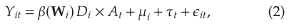

NOTE: contains mathematical notation; text above is the PDF text layer and symbols may be mis-extracted. Image shows the original.

where **W***i* is a *J*-dimensional vector denoting individ ual *i*’s pretreatment features. β(**W***i*) captures the aver age treatment effect conditional on the pretreatment features.

An earlier practice of estimating heterogeneous treatment effect is to assume a functional form of β(**W***i*) and estimate it accordingly. For example, there are existing works, including three-way interactions *Di* × *At* × **W***i* in the DiD model, to examine treatment effect heterogeneity (see, e.g., Duflo 2003), which is equivalent to assuming β(**W***i*) as a linear function of **W***i*. However, there can be complex interactions between these pretreatment features. A linear func tional form of β(**W***i*) cannot take into account the possible complex interactions between pretreatment features, and it is hard for researchers to know the cor rect specification ex ante. Therefore, this method may give a directional sense of how the treatment effect

changes with a certain variable, but it may lead to biased estimates if the goal is to obtain an accurate estimate of individual-level HTEs.

Nonparametric approaches to estimation of hetero geneous treatment effects include nearest-neighbor matching, kernel methods, and series estimation. As the dimension of pretreatment features gets large, the performance of these methods deteriorates (Wager and Athey 2018), and it calls for the utilization of machine-learning methods. Wager and Athey (2018) and Athey et al. (2019) proposed to estimate heteroge neous treatment effects using random forests.

Farrell et al. (2021) showed that deep neural net works (DNN) can be used in semiparametric infer ence. More specifically, they showed that DNN can be used to estimate the nonparametric part (they call it a “nuisance function”) in the first-step estimation with a fast enough convergence rate, which enables a valid second-step inference<sup>4</sup> of the parametric part. They showed the application of this method on estimating average causal parameters. Farrell et al. (2020) further presented a DNN-based framework that could estimate fully flexible nonparametric individual heterogeneity.

Inspired by this line of works, we innovatively inte grate DNN with the DiD model to estimate β(**W***i*). We call it the *Deep-DiD* approach. We consider a more general setup, where the individual fixed effects and time fixed effects may interact and are represented by a general functional form *f*(*µi*,τ*t*):

*Yit*  β(**W***i*)*Di* × *At* + *f*(*µi*,τ*t*) + *ɛit:* (3)

**equation / math rendering (image)**

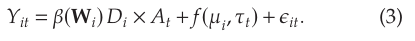

NOTE: contains mathematical notation; text above is the PDF text layer and symbols may be mis-extracted. Image shows the original.

Figure 1 illustrates the conceptual framework of our approach. We use a dual-network architecture in esti mation. One is the HTE estimation network, with **W***i* as the input layer and β*i* as the output layer. This DNN characterizes β*i* as a nonparametric function of **W***i*. The other is the fixed-effect network, with the

**Figure 1.** Deep-DiD Model Architecture

**Cheng et al.:** *A Deep-DiD Method to Estimate Heterogeneous Treatment Effects* 262 Marketing Science, 2026, vol. 45, no. 2, pp. 258–279, © 2026 INFORMS

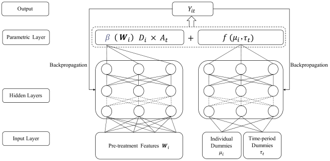

NOTE: figure/graphic rendered as an image from the PDF; its content is not machine-readable text. Caption (if any) follows as the next block.

Page 6

high-dimensional individual dummies and time-period dummies as the input layer and a nuisance function *f*(*µi*,τ*t*) as the parametric layer.<sup>5</sup> As we will show in Section 2.1.2, this design allows for possible complex interactions between individual fixed effects and time fixed effects.

The estimation process is an iterative process. In each iteration, the mean squared loss between the outcome variable *yit* and the sum of β(**W***i*)*Di* × *At* and *f*(*µi*,τ*t*) are computed, and then the parameters in each layer are updated to minimize this loss in the next iteration until convergence is achieved. The heterogeneous treat ment effects β*i*  β(**W***i*)’s are retrieved from the para metric layer of the HTE estimation network.

**2.1. Simulation** We conduct a series of simulations to demonstrate the performance of our Deep-DiD method. In particular, in a DiD setup with heterogeneous treatment effects as described by Equation (3), our Deep-DiD method can recover the true distribution of β(**W***i*) with high enough accuracy.

**2.1.1. Simulation Procedure.** Let us first describe the data-generating process. We generate (**W***i*,*µi*,τ*t*,*Di*,*At*) (*i*  1,*:::*,*N*,*t*  1,*:::*,*T*), where **W***i* is a *J*-dimensional vector, according to certain distribution assumptions. Unless otherwise specified, we assume that each element in **W***i* is independent and follows a normal distribution *N*(5,3). Individual fixed effects *µi* are all independent and follow a normal distribution *N*(0,5) (*i*  1,*:::*,*N*). Time fixed effects τ*t* are also indepen dent and follow *N*(0,1) (*t*  1,*:::*,*T*). We consider a setting that the treatment assignment is based on observables rather than random, which makes the estimation task more challenging. In particular, we assume that each individual *i* is treated with probability Pr(*Di*  1)  (1 + exp(<sup>P</sup>

For the training data set, we further randomly split it into 80% for model training and 20% for validation. We use the training set to train the model and use MSE loss on the validation set to monitor the training progress to prevent overfitting. In both networks, we

design two hidden layers. Unless otherwise specified, we set each hidden layer with 32 neurons. Rectified linear unit (ReLU) activation functions are used between layers, which is a common and effective choice for neural network architectures. We set the batch size as 512 and the number of epochs as 10. We use the Adaptive Moment Estimation (Adam) opti mizer. The learning rate is initialized at 0.001 and halved if the model’s performance fails to improve for two consecutive evaluation periods.<sup>7</sup>

The trained model essentially provides us with an estimated (nonparametric) function <sup>ˆ</sup>β(·). We apply it to the test set to calculate <sup>ˆ</sup>β*i*  <sup>ˆ</sup>β(**W***i*) for each *i* in the test set. To evaluate the estimation performance, we compare the distribution of <sup>ˆ</sup>β*i*s to the distribution of true β*i*s of the test sample. We employ two commonly used metrics to quantify the difference between the two distributions: the Kolmogorov-Smirnov (KS) Sta tistic and the Jensen-Shannon (JS) Divergence. The KS Statistic, ranging from 0 to 1, represents the maximum vertical distance between the two cumulative distribu tion functions (CDFs) and is widely used in statistical analysis. The JS Divergence, also ranging from 0 to 1 when implemented in Python Scipy, is a symmetrized and smoothed version of the Kullback-Leibler diver gence. For both metrics, lower values indicate greater similarity between the two distributions.<sup>8</sup> To further evaluate whether our method accurately predicts the value of each β*i* (beyond distribution matching), we also use a third metric: Normalized Root Mean Square

Error (NRMSE)

**equation / math rendering (image)**

NOTE: contains mathematical notation; text above is the PDF text layer and symbols may be mis-extracted. Image shows the original.

**equation / math rendering (image)**

NOTE: contains mathematical notation; text above is the PDF text layer and symbols may be mis-extracted. Image shows the original.

*=*σβ, which is the root of mean square error divided by the standard deviation. Whereas both mean squared error (MSE) and root mean squared error (RMSE) depend on the scale of the variable of interest, making it hard to eval uate and compare the estimation performance across different tasks, NRMSE is scale independent and comparable across different data sets with different scales. It is usually considered an excellent fit when NRMSE*<*0.1.

All simulations are conducted on a local Windows 11 desktop with an Intel Core i9-14900KF processor and an NVIDIA GeForce RTX 4090 graphics card (24GB VRAM). The Python environment comprised CUDA 11.8, PyTorch 2.3.1, and Python 3.10.14.

**2.1.2. Simulation Results. *Performance of Deep-DiD Under Various Settings.*** First, we show that under different assumptions for the true functional forms of β(·) and *f*(·,·), the true β*i*s can be well uncovered using our Deep-DiD method (Figure 2). We try two different assumptions for the true functional forms of β(·) (linear, nonlinear) and three for *f*(·,·) (additive, multiplicative, and cyclical).

**Cheng et al.:** *A Deep-DiD Method to Estimate Heterogeneous Treatment Effects* Marketing Science, 2026, vol. 45, no. 2, pp. 258–279, © 2026 INFORMS 263

Page 7

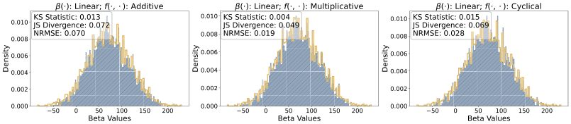

NOTE: figure/graphic rendered as an image from the PDF; its content is not machine-readable text. Caption (if any) follows as the next block.

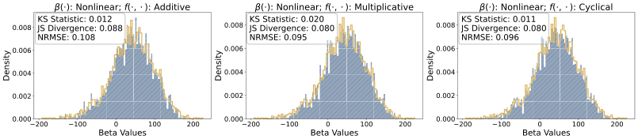

NOTE: figure/graphic rendered as an image from the PDF; its content is not machine-readable text. Caption (if any) follows as the next block.

There are 2 × 3  6 combinations in total. The detailed specifications are listed in the note of Figure 2. The results demonstrate that the true β*i*s can be estimated accurately across different functional forms of the het erogeneous treatment effect β(·) and fixed effects *f*(·,·).

Third, we examine what happens if there are two different groups of individuals drawn from different distributions. In particular, we assume half of the pop ulation is a high-performing population, with each element in **W***i* drawn from *N*(8,3) and individual fixed effects *µi* drawn from *N*(2,5); the other half of the population is low-performing, with each element

in **W***i* drawn from *N*(5,3) and individual fixed effects *µi* drawn from *N*(0,5). We assume that each individ ual *i* is treated with probability Pr(*Di*  1)  1*=*[1+ exp(*MinMax*(*Wi*1+*Wi*2+*Wi*3+*µi*))], where *MinMax*(·) means a min-max normalization function. Note that the assumed Pr(*Di*  1) increases with *Wi*1 + *Wi*2+ *Wi*3 + *µi*, so the treated group will consist of more individuals from the high-performing population, and the control group will consist of more from the low-performing population. This reflects the case when there is systematic difference between the treated and control groups, and the difference is contributed by both observable and unobservable features.<sup>9</sup> As shown in Figure 4(a), our model estimation can still uncover the true distribution of β*i*s in this case. In addi tion, we consider the case when there is also a shift in time fixed effects τ*t*, which reflects time-variant con founders that affect all individuals equally or ran domly. Specifically, we assume that τ*t* follows *N*(0,1) before treatment and *N*(2,1) after treatment. The model estimation still performs well, as shown in Figure 4(b).

Fourth, we examine the performance of our approach across different implementation choices in the estimation procedure: the optimizer {Adam, SGD} (SGD stands for stochastic gradient descent), the num ber of notes in each layer of the DNN {32, 64}, the batch size {512, 1024}, the learning rate {0.001, 0.005}, and the number of epochs {5, 10}.<sup>10</sup> Table 2 shows the estimation performance (i.e., KS statistic, JS diver gence, and NRMSE, all calculated on the test set) under different parameter values. In each row, the reported values are averaged across 10 simulations.

**Figure 2.** (Color online) Estimation Performance of Deep-DiD Across Different Functional Forms of β(·) and *f*(·,·)

*Notes*. Two functional forms of β(**W***i*): linear (15*Wi*1 2*Wi*2 + *Wi*3) and nonlinear (15*Wi*1 (*Wi*2)<sup>2</sup> + sin(*Wi*3)). Three functional forms of *f*(*µi*,τ*t*): additive *µi* + τ*t*, multiplicative *µi* ∗τ*t*, and cyclical *sin*(*µi*) ∗*cos*(τ*t*). In each combination, we set *N*3,000, *T*90, *J*100.

**Cheng et al.:** *A Deep-DiD Method to Estimate Heterogeneous Treatment Effects* 264 Marketing Science, 2026, vol. 45, no. 2, pp. 258–279, © 2026 INFORMS

Page 8

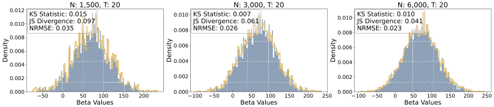

NOTE: figure/graphic rendered as an image from the PDF; its content is not machine-readable text. Caption (if any) follows as the next block.

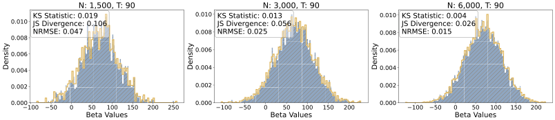

NOTE: figure/graphic rendered as an image from the PDF; its content is not machine-readable text. Caption (if any) follows as the next block.

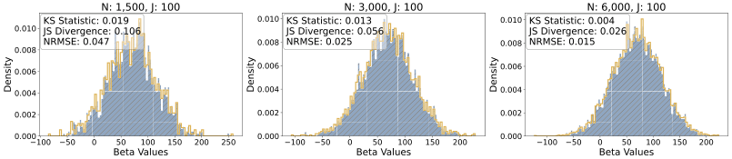

NOTE: figure/graphic rendered as an image from the PDF; its content is not machine-readable text. Caption (if any) follows as the next block.

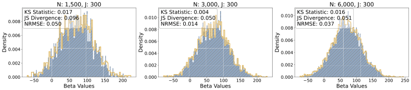

NOTE: figure/graphic rendered as an image from the PDF; its content is not machine-readable text. Caption (if any) follows as the next block.

We find that the SGD optimizer does not work well in our simulation settings. When the optimizer is Adam, the model estimation performs well, and the estima tion performance is not very sensitive to other imple mentation choices.

*Deep-DiD vs. Linear Model and Random Forests.* Next, we compare the performance of Deep-DiD method versus representative existing approaches.

We first show that our method has more robust per formance than a conventional parametric approach; that is, if we do not use DNN but rather assume a spe cific functional form (e.g., a linear model) for β(**W***i*) or *f*(*µi*,τ*t*) in the estimation, the estimated distribution of β*i*s can be largely biased.

We first test what happens if we assume that β(·) is a linear function (see the Figure 5(a), top row).<sup>11</sup>

When the true β(**W***i*) is a nonlinear function of **W***i*, the

**Figure 3.** (Color online) Estimation Performance of Deep-DiD Under Different Sample Sizes and Feature Dimensions

(a)

(b)

*Notes*. In both subfigures, the true functional form of β(**W***i*) is (15*Wi*1 2*Wi*2 + *Wi*3). The true functional form of *f*(*µi*,τ*t*) is *µi* ∗τ*t*. In (a), we set *J*  100. In (b), we set *T*  90. The number of epochs is set to 20 when *N*1,500, *T*20 in (a) and 10 in all the other cases.

**Cheng et al.:** *A Deep-DiD Method to Estimate Heterogeneous Treatment Effects* Marketing Science, 2026, vol. 45, no. 2, pp. 258–279, © 2026 INFORMS 265

Page 9

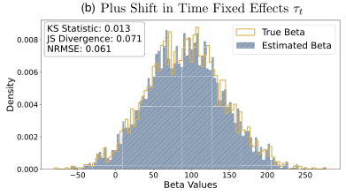

NOTE: figure/graphic rendered as an image from the PDF; its content is not machine-readable text. Caption (if any) follows as the next block.

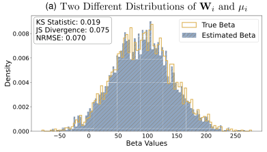

NOTE: figure/graphic rendered as an image from the PDF; its content is not machine-readable text. Caption (if any) follows as the next block.

estimated distribution of β*i*s is largely different from the true distribution (Figure 5(a), top right). Surpris ingly, even when the true β(**W***i*) is a linear function of **W***i* (but includes only some elements of **W***i* in the function), the linear model estimation performs poorly (Figure 5(a), top left). We find that only when the true β(**W***i*) is linear and includes all elements of **W***i* (called the “linear-all” case) does the linear model accurately capture the true value of β*i*s (Figure 5(a), top middle). The contrast between the linear and linear-all cases indi cates that linear models are poor at variable selection; that is, they cannot accurately identify which pretreat ment features’ variations contribute to the variations in β*i*s. This explains why linear models may yield inaccu rate estimates even when the true functional form is lin ear. In contrast, when we use DNNs to estimate β(·) (in Figure 5(a), bottom row), the estimated values of β*i*s closely approximate the true values, no matter whether the true functional relationship is linear (bottom left), linear-all (bottom middle), or nonlinear (bottom right).

In Figure 5(b), we test what happens if we assume that *f*(·,·) is a linear function in estimation. When the true *f*(·,·) is linear, which means that the true individual fixed effects and time fixed effects are just additive, the

linear model works and performs as well as using DNN to estimate the nuisance function (Figure 5(b), left column). When the true *f*(·,·) is nonlinear—specifically multiplicative—the linear model yields biased estimates of β*i*’s (Figure 5(b), top right), whereas our DNN approach still uncovers the true β*i*’s effectively (Figure 5(b), bottom right). To summarize, our Deep-DiD method exhibits remarkable adaptability, successfully capturing both linear and nonlinear relationships without requiring a prior specification of the functional form.

Furthermore, we compare DNN to random forests. Note that combining random forests with a DiD model with fixed effects is challenging and has not been solved as far as we know, and it is beyond the scope of this paper to address this issue.<sup>12</sup> Thus, we set aside the DiD setting for now and focus solely on functional approximation. The comparison between the estimated and true values of β*i*s is displayed in Figure 6, with the implementation details provided in the figure note. This figure shows that DNN outperforms random forests in uncovering true β*i*s, demonstrating DNN’s superior performance in functional approximation compared with random forests.

**Figure 4.** (Color online) Estimation Performance of Deep-DiD with Observable Differences and Unobservable Confounders

(a) (b)

*Notes.* In both subfigures, the true functional form of β(**W***i*) is (15*Wi*1 2*Wi*2 + *Wi*3). The true functional form of *f*(*µi*,τ*t*) is *µi* + τ*t*. *N*3,000, *J*100, *T*90.

**Table 2.** Estimation Performance of Deep-DiD Across Different Implementation Choices

|  |  | No. of nodes in | Batch | Learning |  | KS | JS |  |
| --- | --- | --- | --- | --- | --- | --- | --- | --- |
| No. | Optimizer | eachhiddenlayer | size | rate | Epochs | statistic | divergence | NRMSE |
| 1 | Adam | 32 | 512 | 0001 . | 10 | 0015 . | 0071 . | 0061 . |
| 2 | Adam | 64 | 512 | 0001 . | 10 | 0015 . | 0077 . | 0085 . |
| 3 | Adam | 32 | 1024 | 0001 . | 10 | 0014 . | 0066 . | 0045 . |
| 4 | Adam | 32 | 512 | 0005 . | 10 | 0021 . | 0083 . | 0101 . |
| 5 | Adam | 32 | 512 | 0001 . | 5 | 0016 . | 0070 . | 0057 . |
| 6 | SGD | 32 | 512 | 0001 . | 10 | 0523 . | 0793 . | 1008 . |
| 7 | SGD | 64 | 512 | 0001 . | 10 | 0507 . | 0792 . | 1000 . |
| 8 | SGD | 32 | 1024 | 0001 . | 10 | 0529 . | 0792 . | 1021 . |
| 9 | SGD | 32 | 512 | 0001 . | 5 | 0535 . | 0793 . | 1023 . |
| 10 | SGD | 32 | 512 | 0005 . | 10 | 0903 . | 0958 . | 1263449794 , , . |

NOTE: table converted from PDF layout to HTML text; cell boundaries are reconstructed. See PDF if exact alignment matters.

*Notes.* The true functional form of β(**W***i*) is (15*Wi*1 2*Wi*2 + *Wi*3). The true functional form of *f*(*µi*,τ*t*) is *µi* + τ*t*. We set *N*3,000, *T*90, *J*100.

**Cheng et al.:** *A Deep-DiD Method to Estimate Heterogeneous Treatment Effects* 266 Marketing Science, 2026, vol. 45, no. 2, pp. 258–279, © 2026 INFORMS

Page 10

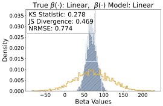

NOTE: figure/graphic rendered as an image from the PDF; its content is not machine-readable text. Caption (if any) follows as the next block.

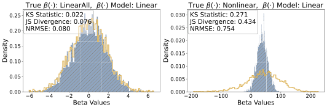

NOTE: figure/graphic rendered as an image from the PDF; its content is not machine-readable text. Caption (if any) follows as the next block.

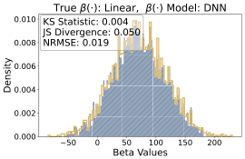

NOTE: figure/graphic rendered as an image from the PDF; its content is not machine-readable text. Caption (if any) follows as the next block.

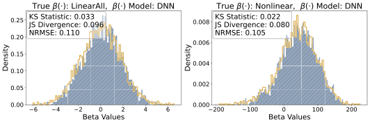

NOTE: figure/graphic rendered as an image from the PDF; its content is not machine-readable text. Caption (if any) follows as the next block.

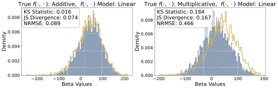

NOTE: figure/graphic rendered as an image from the PDF; its content is not machine-readable text. Caption (if any) follows as the next block.

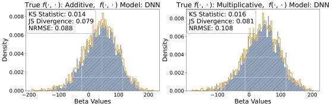

NOTE: figure/graphic rendered as an image from the PDF; its content is not machine-readable text. Caption (if any) follows as the next block.

Compared with random forests, DNN not only has superior performance in functional approximation but also has the following advantages in estimating HTE. First, DNN can be implemented on production-level deep learning platforms like PyTorch. This highly mature platform guarantees stability and scalability, making the processing of extensive data and large

number of covariates notably seamless. Second, as mentioned above, it is still yet unknown to us how the generalized random forest approach can deal with large-dimensional fixed effects.

**2.1.3. Discussion.** Note that the findings above are based on a well-defined simulation setting where

**Figure 5.** (Color online) Robustness of DNN: Compare DNN to Linear Model

(a)

(b)

*Notes.* In all simulations, we set *N*  3,000, *T*  90, and *J*  100. In (a), the true functional forms of β(**W***i*) are linear (15*Wi*1 2*Wi*2 + *Wi*3), linear-all (<sup>P</sup>*<sup>J</sup>*

*j*1

**equation / math rendering (image)**

NOTE: contains mathematical notation; text above is the PDF text layer and symbols may be mis-extracted. Image shows the original.

α*j*

**Cheng et al.:** *A Deep-DiD Method to Estimate Heterogeneous Treatment Effects* Marketing Science, 2026, vol. 45, no. 2, pp. 258–279, © 2026 INFORMS 267

Page 11

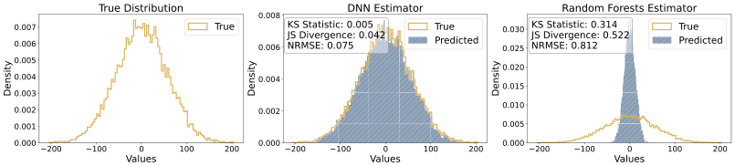

NOTE: figure/graphic rendered as an image from the PDF; its content is not machine-readable text. Caption (if any) follows as the next block.

theoretical expectations are closely met. Real-world scenarios often introduce more complexities and nuan ces, which may require adjustments of the architecture and hyperparameters of DNNs, including those that showed less sensitivity in our simulations.

One may wonder, in a real-world application (rather than a simulation task) where the true treat ment effects are unobservable, how we can assess the model’s performance and, furthermore, how to select the architecture and hyperparameters for the DNNs in the model. It is important to note that we are not training the model using observed treatment effects but rather using observed *Yi*’s. Essentially, our method estimates the individual-level treatment effect β*i* as a function of individual pretreatment features **W***i* based on the equation β*i*  E[*Y*(1)|**W***i*] E[*Y*(0)|**W***i*], where *Y*(*d*) ≡*Y*(*Di*  *d*),*d*  0,1. For each individual *i*, only one of the {*Y*(1),*Y*(0)} is observed because he or she was either treated or untreated, and the other’s expected value (as a function of **W***i*) is predicted by the model. More specifically, we learn the relationship between *Y*(*d*) and **W***i* based on the individuals whose *Y*(*d*) are observable and then predict E[*Y*(*d*)|**W***i*] for individuals whose *Y*(*d*) are unobservable (*d*  0,1). Therefore, although the final output is an estimated causal effect, our method fundamentally remains a prediction task. As with other prediction problems, performance can be evaluated using measures such as MSE, which quantify the discrepancy between predicted

ˆ*Yi*s and actual *Yi*s observed. The way of choosing the DNN architecture and hyperparameters is similar to other prediction tasks. Existing literature offers practical guidelines for these choices (see, e.g. Bengio 2012, Goodfellow et al. 2016, and Aggarwal 2018). Architec ture selection typically starts from matching the archi tecture to the data modality: Multi-Layer Perceptrons (MLPs) for tabular data, Convolutional Neural Net works (CNNs) for images, or Recurrent Neural

Networks (RNNs) for sequential data. The selection of network depth, width, activation functions, and train ing configurations such as the optimizer (e.g., Adam, SGD) and learning rate usually requires systematic experimentation. In this process, the training and vali dation losses are closely monitored to diagnose issues like overfitting or underfitting. A simple baseline often serves as a good starting point. In the context of this paper, a baseline MLP with two to three hidden layers has proven very effective, as shown in our simulations and empirical application (Section 4).

**3. Empirical Background** We apply our Deep-DiD method to a real-world empirical setting to estimate the HTEs of a specific treatment. We collaborate with a large short-video sharing platform that was expanding their global user base. As part of its global growth strategy, the plat form launched a “Creator Signing Program” in three countries located in South America, Africa, and Europe. The program aimed to incentivize content creators to upload more high-quality original content to the plat form. Selected creators were able to sign a contract with the platform to join the program.<sup>13</sup> After joining the program, they received monthly payments by the plat form based on their performance during the month. We apply our approach to estimate the HTEs of this signing program and show how our estimation results can help the platform optimize its creator selection.

We focus on creators from the three countries who were signed from May 1, 2022, to June 30, 2022.<sup>14</sup>

Because there is a very large number of unsigned creators—far too many to include all in our analyses— we construct a control group from the pool of unsigned creators (as of data collection) by matching them with signed creators. Our matching procedure is unconventional in the sense that we match on crea tors’ trends of outcome measures rather than their

**Figure 6.** (Color online) Compare DNN to Random Forests

*Notes.* We simulate a data set with *N*  50,000 and *J*  100. *Wij*’s (*i*  1,*:::*,*N*,*j*  1,*:::*,*J*) are i.i.d., following a uniform distribution *U*(10,10). The true functional form of β(**W***i*) is β(**W***i*)  5sin(*Wi*1) + 2cos(*Wi*2*Wi*3) + 3exp(((*Wi*4 2)<sup>2</sup> + (*Wi*5 + 1)<sup>2</sup>)*=*10) + <sup>P</sup><sup>100</sup>

*j*6 *<sup>W</sup><sup>ij</sup>*<sup>. Other specifications are</sup> the same as that described in Section 2.1.1. We train the DNN and the random forest models on the training set to get an estimated relationship

ˆβ(**W***i*) and then evaluate the model performance by comparing the estimated ˆβ*i* with the true β*i* in the test set. For the random forest model, we use the RandomForestRegressor from scikit-learn with 100 trees. For the DNN model, we implement a Multi-Layer Perceptron (MLP) in PyTorch with two hidden layers of 128 and 64 neurons, with both using ReLU activation functions. The model is trained for 20 epochs.

**Cheng et al.:** *A Deep-DiD Method to Estimate Heterogeneous Treatment Effects* 268 Marketing Science, 2026, vol. 45, no. 2, pp. 258–279, © 2026 INFORMS

Page 12

mean levels. A conventional matching procedure selects untreated individuals who are similar to treated indivi duals based on observable characteristics, aiming to construct a comparable control group such that the treatment assignment is as good as random. After a conventional matching procedure, treatment effects can be estimated by directly comparing posttreatment means between treated and control groups. In our set ting, however, signed creators are systematically differ ent from unsigned creators; they generally demonstrate higher performance measures even before the treat ment. Thus, constructing a control group that is sta tistically indifferent from the treated group through conventional matching is challenging.<sup>15</sup> Nevertheless, DiD requires only that the treated and control groups exhibit parallel trends in outcome measures before treatment, not that they be statistically indifferent before treatment.<sup>16</sup> Therefore, we match on the trends of out come measures, aiming to construct a control group that exhibits parallel pretreatment trends with the trea ted group. In particular, for each creator who uploaded at least five videos<sup>17</sup> from February 1 to April 30, 2022, we estimate the trend of each performance measure using a linear regression. Because signed creators have different signing dates (after May 1) and unsigned crea tors do not have signing dates, we use data in the com mon period, February 1 to April 30, to estimate the trends. Then, we conduct propensity score matching (PSM), with the estimated trends as matching variables. More details of the matching procedure are available in Online Appendix A.1.<sup>18</sup>

The matched data set comprises 2,343 creators in the signed group and 2,343 creators in the control group. In Online Appendix Table A.2, we test that the signed group and the control group have parallel pre treatment trends for all outcome measures. In particu lar, we regress the creator-day level outcome measures on *Treated* × *# Days to Signing Date*, with creator fixed effects and day fixed effects controlled for. Part A of the table uses observations from May 1, 2022, to each crea tor’s signing date. Because the matching procedure uses the data of February 1–April 30, 2022, using the data from May 1 to the signing date to test the parallel trend is an “extrapolation” test,” which can be considered as a test of the assumption that the treatment and control groups would have followed the parallel trajectories over time in the absence of treatment. Part B of the table uses an extended period from February 1, 2022, to each creator’s signing date. Both Part A and Part B show sta tistically insignificant coefficients for the interaction term *Treated* × *# Days to Signing Date* across all outcome measures, supporting the parallel-trend assumption.

For each creator, we designated their signing date as Day 0 and collected data of the 89 days before<sup>19</sup>

and 90 days after the signing date (including the sign ing date). For control group creators, we defined their

Day 0 as the signing date of their matched treated cre ator. The data we obtained included (1) creator fea tures, like the number of followers a creator has and how many users a creator is following, the creator’s gender, country, etc.; (2) creators’ production, like the number of videos a creator uploads on a day; (3) video viewing, that is, the number of views, the number of completed views, and the total play duration each video has; (4) users’ interactions (engagement beha viors), that is, the number of likes, comments, shares, and follows<sup>20</sup> each video has, and (5) visual and audio features of each video. We will elaborate more on these variables in Sections 3.1 and 4.1, when we define and construct the outcome variables and input variables.

**3.1. Outcome Variable: Measurement of Creator Performance** To study the effect of the signing program on creators’ performance and how the platform should select crea tors to sign, we first need to determine how to mea sure a creator’s performance.<sup>21</sup> The goal of the signing program is to incentivize creators to contribute more videos with original content and higher quality, and these videos in turn can attract users to spend more time and have more interactions on the platform. These make the platform a prosperous content plat form and attract more users in the long run. There fore, when choosing the key performance measures, we focus on how to measure a creator’s contribution to the platform in these aspects. Based on this princi ple and communication with managers in the com pany, we choose two key performance measures, as illustrated below.

The first performance measure is *User Time Contrib uted*, meaning the cumulative time length that the creator’s videos have been watched by all viewers. This measure is important to the platform because it captures how much user screen time the video contri butes to the platform, which is directly related to the platform’s profitability. The platform cares not only about how much time users spend on the platform but also about whether users get engaged and interact on the platform, which can be measured by how many likes, comments, shares, and follows a video gets. These responses reflect different degrees of user engagement (Brodie et al. 2011, Oestreicher-Singer and Zalmanson 2013, Yang et al. 2019). To offer a holistic measure of engagement, we integrate these four engagement measures by performing Principal Component Analysis (PCA) and take the first compo nent as the *User Engagement* measure. Therefore, we determine two key performance measures of creators, *User Time Contributed* and *User Engagement*, both of which are defined at the creator-day level.<sup>22</sup> Table 3 presents the summary statistics of the two perfor mance measures.

**Cheng et al.:** *A Deep-DiD Method to Estimate Heterogeneous Treatment Effects* Marketing Science, 2026, vol. 45, no. 2, pp. 258–279, © 2026 INFORMS 269

Page 13

Note that our approach does not hinge upon our choice of performance measures, and it can be applied easily when other measures are chosen as the outcome variable. For example, a platform may define a weighted sum of these two performance measures as the single key performance measure. Then they can easily calculate that measure and use it as the outcome variable when applying our method.

**3.2. Impact of the Signing Program on Creator Performance** We first graphically show the effect of the signing pro gram on creator performance. For each performance measure, Figure 7 shows its daily average value of creators in the signed group versus in the control group in the 89 days before and 90 days after Day 0.

We can see that the signed group has a significant jump in both performance measures after Day 0, and both performance measures are relatively stable in the 90 days after Day 0, implying that the positive impacts on *User Time Contributed* and *User Engagement* of signed creators tend to be long-lasting.

To quantify the impact of the signing program on creator performance, we conduct DiD analyses as sug gested by model (1), as shown in Table 4. Columns (1) and (3) report the results when the Treated dummy (*Di*) and After dummy (*At*) are included in the regres sion, and Columns (2) and (4) show the results when creator and day fixed effects are controlled for. For both performance measures, the coefficients of the

interaction term are positive and statistically signifi cant, and their magnitudes are relatively stable after we control for fixed effects.<sup>23</sup> The relative effect size of the treatment is larger than 100% for both perfor mance measures. To summarize, the DiD regression results show that the signing program has a signifi cant and substantial positive impact on signed crea tors’ performance, which is measured by the amount of user watching time and engagement contributed by the videos.

**4. Using Deep-DiD to Estimate the Heterogeneous Treatment Effects of the Signing Program** Now we apply the Deep-DiD method to the empirical setting to estimate the heterogeneous treatment effects of the signing program.

In Section 4.1, we describe how we construct crea tors’ pretreatment characteristics **W***i*. In Section 4.2, we provide the details of the model estimation techni ques and estimation results.

**4.1. Creators’ Pretreatment Features** We construct the pretreatment features of creators **W***i*, utilizing the rich data we have as much as possible. We not only make use of the structured data describ ing creators’ production behaviors and viewers’ responses but also utilize the video and audio features, which are derived from unstructured video data using

**Table 3.** Summary Statistics of Outcome Variables

|  | Mean | SD . . | Median | Min | Max | N |
| --- | --- | --- | --- | --- | --- | --- |
| Usertimecontributed | 3342299 , . | 60047410 , . | 0 | 0 | 1 .315e+07 | 838794 , |
| Userengagement | 0010 . | 1816 . | 0112 . | 0112 . | 469509 . | 838794 , |

NOTE: table converted from PDF layout to HTML text; cell boundaries are reconstructed. See PDF if exact alignment matters.

*Notes.* This table is based on the data of all 2,343*2 creators in the matched data set. Observations are at the creator-day level. Each creator has 179 observations: 89 days before the signing date and 90 days after the signing date (including the signing date). Notice that *User Engagement* has negative values because it is the first component of PCA, which has been normalized following the standard normal distribution.

**Figure 7.** The Impact of the Signing Program on Creator Performance

(a) (b)

**Cheng et al.:** *A Deep-DiD Method to Estimate Heterogeneous Treatment Effects* 270 Marketing Science, 2026, vol. 45, no. 2, pp. 258–279, © 2026 INFORMS

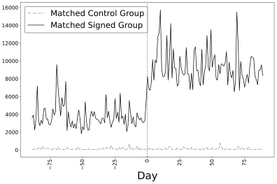

NOTE: figure/graphic rendered as an image from the PDF; its content is not machine-readable text. Caption (if any) follows as the next block.

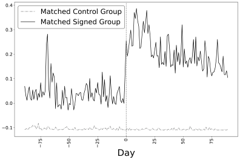

NOTE: figure/graphic rendered as an image from the PDF; its content is not machine-readable text. Caption (if any) follows as the next block.

Page 14

deep-learning-based methods. We encountered some data loss in this process because some videos had been deleted by creators and become unavailable for downloading. We remove the creators who have more than 10% of videos missing. After this step, we are left with 2,204 creators, among which 1,126 are from the treated group and 1,078 are from the control group. The results of conventional DiD analyses based on this reduced data set (see Online Appendix A.3) are very close to the full sample results as shown in Figure 7 and Table 4.

In the following, we describe how we construct variables in **W***i*. We classify the creator features into three categories: (1) creators’ production behavior and viewers’ responses, (2) visual features, and (3) audio features.

For the first category, *creators’ production behavior and viewers’ responses*, we include variables that describe a creator’s production quantity (*Production*, meaning the number of videos uploaded on the day), viewers’ viewing behavior (*Num of Plays*, meaning how many times the creator’s videos were played by viewers on the day; *Num of Complete Plays*, meaning how many times the creator’s videos were watched by viewers from the beginning to the end on the day; and *Play Duration*, meaning the total time length that the creator’s videos were watched by viewers on the day), and viewers’ interactions with the creator (*Num of*

*Likes*, *Num of Comments*, *Num of Shares*, *Num of Follows*, meaning the total number of likes, comments, shares, and follows the creator’s videos get on the day). We also include variables that describe the creator’s account status on the platform: how many followers the creator has on the day (*Num of Followers*) and how many users the creator is following on the day (*Num of Following Users*). To reduce the dimension of **W***i*, we aggregate these variables from the creator-day level to the creator level by taking the mean, median, mini mum (min), maximum (max), and standard deviation (SD) of each variable for each creator, using observa tions in the 89 days before the signing date. Further more, to capture the trend of changes, we also calculate the slope of each variable for each creator to include in **W***i*. The slope of a variable captures whether and by how much this variable is increasing, decreasing, or remaining relatively steady for a creator.

A video can be considered as a combination of a large number of consecutive images plus audio. The manner in which the content is visually and aurally presented to the audience can directly impact users’ watching experience and thus can influence their will ingness to continue watching and get engaged (see, e.g., Li et al. 2019, Hwang et al. 2021, Wang et al. 2021, Zhou et al. 2021, Cheng and Zhang 2024, and Yang et al. 2025). Having access to the videos uploaded by creators, we are able to extract visual and audio fea tures from them to be included in **W***i*. For *visual fea tures*, we use eight visual quality measures, including *Blur Probability*, *Blocky Probability*, *Dirty Lens Probabil ity*, *Noise Probability*, *Colorfulness*, *Defocus Probability*, *Aesthetic Score*, and *Quality Score*, as well as one simi larity measure for each video. For *audio features*, we include five measures, which are *Audio Quality*, *Stereo phonic Richness*, *Background Noise Probability*, *Dialog Probability*, and *Music probability*. For each visual fea ture and audio feature, we aggregate these video level measures to the creator level as the model input; for each creator and each measure, we take the mean, median, min, max, and SD of the measure on all the videos uploaded by the creator in the 89 days before the signing date and include these five summary sta tistics in **W***i*.

In Online Appendix A.4, we provide more detailed explanations of the variables mentioned above, why we choose them, and how we calculate them as well as their summary statistics.

**4.2. Model Estimation and Results** We apply the Deep-DiD method to estimate the HTE of the signing program on creators’ performance. The implementation is similar to what we describe in Sec tion 2.1.1, with some differences that are due to the complexities in data from a real-world setting. We describe the key techniques below.

**Table 4.** The Impact of the Signing Program on Creator Performance: DiD Analyses

|  | Y:Usertime |  | Y:User |  |
| --- | --- | --- | --- | --- |
|  | contributed |  | engagement |  |
| X | (1) | (2) | (3) | (4) |
| Treated×After | 5458946*** , . | 5465047*** , . | 01659*** . | 01661*** . |
|  | (719306) . | (727049) . | (00195) . | (00198) . |
| Treated | 3716215*** , . |  | 01481*** . |  |
|  | (556457) . |  | (00182) . |  |
| After | 55291 . |  | 00030 . |  |
| CreatorFE | (239079) . | Yes | (00021) . | Yes |
| NaturaldayFE |  | Yes |  | Yes |
| Daystosigning |  | Yes |  | Yes |
| dateFE |  |  |  |  |
| Relativeeffect | 14690% . |  | 11202% . |  |
| size |  |  |  |  |
| N | 838794 , | 838794 , | 838794 , | 838794 , |
| Adj R2 . | 00039 . | 01823 . | 00050 . | 01615 . |

NOTE: table converted from PDF layout to HTML text; cell boundaries are reconstructed. See PDF if exact alignment matters.

*Notes.* User Time Contributed is in minutes. “FE” stands for fixed effects. “Natural Day FE” means dummies represent the natural day (e.g., May 1, May 2… ), whereas “Days to Signing Date FE” are dummies representing the number of days that the current day is before (negative value) or after (positive value) the signing date. The relative effect size is calculated using the coefficient of the interaction term divided by the coefficient of *Treated* dummy. Standard errors are clustered at the creator level and are shown in the parentheses.

****p <* 0*:*01; ***p <* 0*:*05; **p <* 0*:*1.

**Cheng et al.:** *A Deep-DiD Method to Estimate Heterogeneous Treatment Effects* Marketing Science, 2026, vol. 45, no. 2, pp. 258–279, © 2026 INFORMS 271

Page 15

Because many of the variables in pretreatment fea tures **W***i* can be largely skewed or have outliers, feed ing them to the input layer of the DNN may result in gradient explosion. Therefore, before feeding **W***i* into the model, we preprocess the data using winsoriza tion,<sup>24</sup> log-transformation, and min-max normalization methods. These preprocessing steps are commonly used in deep learning, and they help to avoid gradient explosion and ensure a smooth convergence. More details of the data-preprocessing procedures are avail able in Online Appendix A.5.

**We randomly split** our data into two parts, 60% (1,322 creators) for model training and validation and 40% (882 creators) for out-of-sample testing. Within the first part, 80% of the observations are for model training, and 20% are for validation.<sup>25</sup> The loss func tion we use is the mean squared error (MSE). In the training process, we monitor the reported loss on the validation set to prevent overfitting. We use the Adam optimizer and adopt a learning rate of 0.001. We choose the batch size as 512 and the number of

epochs as 20. We design three fully connected hidden layers of (128, 64, 32) neurons activated by the ReLU function. Note that in the model training process, the number of individuals *N*  1,322, the number of pre treatment features *J*  130, and the total time periods *T*  179. According to our simulation results shown in Section 2.1.2, with this size of data, the Deep-DiD model is able to uncover the true distribution of β*i*s with fairly high accuracy under proper implementa tion choices.

As illustrated in Section 2.1.1, the trained model provides us with an estimated function <sup>ˆ</sup>β(·). We can apply it to calculate <sup>ˆ</sup>β*i*  <sup>ˆ</sup>β(**W***i*) for each *i* in the training-validation set and the test set. To mitigate the randomness in the model training process, we per form the model training 10 times, each time initialized with a different random seed. For each *i*, we take the average value of <sup>ˆ</sup>β*i* across these 10 rounds as the final estimated value of <sup>ˆ</sup>β*i*.<sup>26</sup> The convergence plot in one of the 10 rounds is presented in Online Appendix A.5. Figure 8 shows the in-sample and out-of-sample

**Figure 8.** (Color online) Distribution of Estimated Heterogeneous Treatment Effects <sup>ˆ</sup>β*i*s

(a)

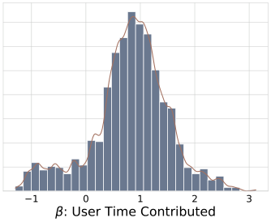

NOTE: figure/graphic rendered as an image from the PDF; its content is not machine-readable text. Caption (if any) follows as the next block.

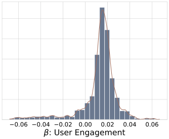

NOTE: figure/graphic rendered as an image from the PDF; its content is not machine-readable text. Caption (if any) follows as the next block.

(b)

**Cheng et al.:** *A Deep-DiD Method to Estimate Heterogeneous Treatment Effects* 272 Marketing Science, 2026, vol. 45, no. 2, pp. 258–279, © 2026 INFORMS

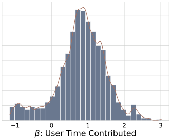

NOTE: figure/graphic rendered as an image from the PDF; its content is not machine-readable text. Caption (if any) follows as the next block.

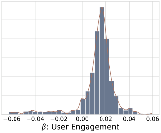

NOTE: figure/graphic rendered as an image from the PDF; its content is not machine-readable text. Caption (if any) follows as the next block.

Page 16

distributions of the estimated heterogeneous treat ment effects <sup>ˆ</sup>β*i*s, which are averaged over 10 rounds, for the two performance measures. We also present the distributions of <sup>ˆ</sup>β*i*s from one of the 10 rounds in Online Appendix A.5, Figure A.7. The similarity between the distributions shown in Figure 8 and those in Figure A.7 demonstrates the robustness of our esti mation. The distributions of <sup>ˆ</sup>β*i*s for both performance measures exhibit substantial heterogeneity across creators. The two distributions also exhibit substantial dissimilarities, indicating that they capture distinct aspects of creators’ performances.

**5. Creator Selection** Now we show how our method can help the platform identify the right creators to sign and whether it out performs platform selection. The idea is straightfor ward. The goal of signing a creator is to incentivize the creator to improve his or her performance. Our model estimation gives <sup>ˆ</sup>β(**W***i*), that is, the estimated treatment effect of the signing program on each indi vidual creator’s performance as a function of his or her pretreatment features **W***i*. Given a new set of crea tors, the platform can calculate their estimated treat ment effects <sup>ˆ</sup>β*i*s based on our estimated function <sup>ˆ</sup>β(·) and their pretreatment features **W***i*s. Suppose the plat form plans to select *K* creators out of this set of crea tors; it would then simply select the top *K* creators with the highest <sup>ˆ</sup>β*i*s.

**5.1. Creator Selection by Deep-DiD Model vs. Platform Selection** We test the performance of our estimated model on creator selection using the test set (i.e., out-of-sample). Among the 882 creators in the test set, 441 of them are from the signed group. We label them as *Platform Selected*. To compare the performance of our method to that of platform selection, we identify the same number (441) of creators with the highest β*i*s from the 882 creators in the test sample and label them as *Model Selected*. Here, we set the number of Model Selected creators the same as that of the Platform Selected ones so that the comparison between the two groups is fair. The fewer creators we select, the higher the selection bar (in terms of the estimated treatment effects) can be. Because we have no access to information regard ing the exact cost and monetary benefit of signing a creator, we cannot determine the optimal number of creators to sign.

As a first evaluation, we compare the average esti mated treatment effects (the mean of <sup>ˆ</sup>β*i*s) of *Model Selected* versus *Platform Selected* creators. As shown in Figure 9(a), for both performance measures, the *Model Selected* creators have substantially higher average estimated treatment effects than the *Platform Selected* creators.

One may argue that the comparison above is not a fair comparison because *Model Selected* creators are selected based on <sup>ˆ</sup>β*i*s, and thus, it is not surprising that they have higher average <sup>ˆ</sup>β*i*s than *Platform Selected* creators, although the magnitude of the dif ference cannot be predicted ex ante. To resolve this concern, we come up with a second way to evaluate the performance of our method. For each creator who was actually signed, we can observe how much his or her performance changed after he or she got signed. We define the creator’s average daily performance after the signing date minus that before the signing date as the creator’s *Performance Jump*, which can be considered as the empirically observed “treatment effect” of the creator. The *Performance Jump* can also be negative if the creator’s average daily performance decreased. We divide the 441 signed creators in the test set into two groups:<sup>27</sup> those who are also selected by the model and those who are not selected by the model. We calculate the average performance jump (APJ) for each of these two groups as well as for all 441 signed creators (see Table 5, Part A). We calculate the percentage difference between the APJ of creators selected by the model versus that of all signed crea tors. For both performance measures, the APJs of those selected by the model are substantially larger than those not selected by the model. The percentage difference in APJ between creators selected by the model and all signed creators is above 70% for both performance measures. This evaluation provides fur ther empirical evidence for the superior performance of our method compared with platform selection. That is, the *Model Selected* creators not only have higher estimated treatment effects of the signing pro gram, their actual increase in performance after being signed is also significantly larger than the platform selected ones.

In Online Appendix A.6, we conduct in-sample tests showing that among the 1,322 creators in the training-validation set, Model Selected creators also outperform Platform Selected creators.

**5.2. Creator Selection by Deep-DiD Model vs. Linear Model** To provide another comparison benchmark for the creator selection based on our Deep-DiD model, we also conduct creator selection based on a linear model. That is, we assume that β(**W***i*)  <sup>P</sup>

**Cheng et al.:** *A Deep-DiD Method to Estimate Heterogeneous Treatment Effects* Marketing Science, 2026, vol. 45, no. 2, pp. 258–279, © 2026 INFORMS 273

Page 17

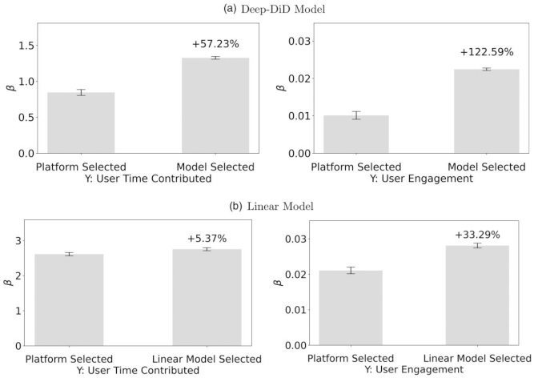

NOTE: figure/graphic rendered as an image from the PDF; its content is not machine-readable text. Caption (if any) follows as the next block.

Then, we apply the estimated linear model to the test set and identify 441 creators with the highest esti mated treatment effects <sup>ˆ</sup>β*i*s, labeled as “Linear Model Selected.” In Figure 9(b), we compare the average esti mated treatment effects of the Linear Model Selected creators versus the Platform Selected creators. We can see that although the Linear Model Selected group has higher estimated treatment effects than the Platform Selected group by design, the percentage

differences between the two groups are much smaller than those between the (Deep-DiD) Model Selected group and the Platform Selected group for both out come measures (5.37% versus 57.23%, 33.29% versus 122.59%). This result indicates that, in expectation, the difference in treatment effects between the Model Selected creators and the Platform Selected creators is larger when the “model” is our Deep-DiD model rather than a simple linear model.

**Table 5.** Actual Performance Jump After Being Signed: Out-Sample

|  |  |  | Usertimecontributed |  |  |  | Userengagement |  |
| --- | --- | --- | --- | --- | --- | --- | --- | --- |
|  | Selected |  | Notselected | Allsigned | Selected |  | Notselected | Allsigned |
|  | bymodel |  | bymodel | creators | bymodel |  | byModel | creators |
| OutcomeY |  | (1) | (2) | (3) |  | (4) | (5) | (6) |
| Part A: Deep-DiD model |  |  |  |  |  |  |  |  |
| Averageperformancejump |  | 21379 . | 00858 . | 12259 . |  | 02094 . | 00284 . | 01174 . |
| N |  | 245 | 196 | 441 |  | 217 | 224 | 441 |
| %Difference |  |  | 74394% . |  |  |  | 78365% . |  |
| PartB:Linearmodel |  |  |  |  |  |  |  |  |
| Averageperformancejump |  | 11334 . | 15966 . | 12259 . |  | 01605 . | 00266 . | 01174 . |
| N |  | 353 | 88 | 441 |  | 299 | 142 | 441 |
| %Difference |  |  | 7545% . |  |  |  | 36712% . |  |

NOTE: table converted from PDF layout to HTML text; cell boundaries are reconstructed. See PDF if exact alignment matters.

*Notes.* “All Signed Creators” means the 441 signed creators (i.e., Platform Selected) in the test set. We divide them into two groups: Selected by Model and Not Selected by Model. The model refers to the Deep-DiD model in part A and refers to the linear model in part B. The “% Difference” is the percentage difference in Average Performance Jump between the “Selected by Model” group and “All Signed Creators.”

**Figure 9.** Average Estimated Treatment Effects of Model Selected Versus Platform Selected: Out-Sample

*Notes*. In both (a) and (b), the Platform Selected group and the (Linear) Model Selected group consist of 441 creators from the test set. Each bar represents the mean value of <sup>ˆ</sup>β*i*s in the group, and the error bar represents the standard error of the mean.

**Cheng et al.:** *A Deep-DiD Method to Estimate Heterogeneous Treatment Effects* 274 Marketing Science, 2026, vol. 45, no. 2, pp. 258–279, © 2026 INFORMS

Page 18

We also calculate the APJ for creators selected by the linear model among all signed creators in the test set and compare it to those not selected by the model as well as all signed creators. Results are provided in Table 5, part B. Comparing the percentage differences listed in part B with those in part A, we find that for both performance measures, our Deep-DiD model leads to a larger improvement in APJ than the linear model. When the outcome measure is *User Time Con tributed*, the linear model even leads to lower APJ compared with all signed creators.

The comparisons above demonstrate the superiority of our Deep-DiD model versus the linear model. We can see that the Deep-DiD model performs consis tently better than the linear model and demonstrates more robust performances across different outcome measures.

Note that the linear model here is estimated in a more modern way than the traditional ordinary least squares (OLS) method; we employ our Deep-DiD model framework but assume both the HTE estima tion network and the fixed-effect network as single- layer (i.e., the input layer connects directly to the output layer without hidden layers). This is equiva lent to assuming that β(·) is linear and the fixed effects are additive. It is mathematically equivalent to OLS because both methods minimize mean squared errors. However, compared with traditional OLS, estimating the linear model by training one-layer neural net works is much more computationally and memory efficient because the data are processed batch by batch and the model’s weights are updated iteratively. This avoids the need to load the entire data set into mem ory and perform a single, massive matrix inversion, as what traditional OLS does. Therefore, our model framework can incorporate the linear model as a spe cial case, and the estimation algorithm makes it

possible to deal with large-scale, high-dimensional data. If estimating the linear model using traditional OLS, we are likely to encounter dimensional explosion because the model contains 130 three-way interaction terms *Wij* ∗*Di* ∗*At* (*j*  1,*:::*,*J*, where *J*  130) as well as high-dimensional individual (*N*1,322) and time (*T*  179) fixed effects. We may have to reduce the number of pretreatment features included in the model, which may further lower the performance of the linear model.

**5.3. Visualization of Model Selected vs. Platform Selected Creators** Next we try to visualize how *Model Selected* creators may differ from those *Platform Selected* creators. As shown in Figure 10, we choose two representative dimensions in each feature category and visualize the two groups of creators on a two-dimensional plane. We use red dots to represent *Model Selected* creators, blue dots to represent *Platform Selected* creators, and gray dots to represent the overlapping creators (i.e., selected both by the model and by the platform). Here, we show only the comparison when the model selection is based on *User Time Contributed* as the out come variable. The comparisons for the other outcome variable are delegated to Online Appendix A.7.

An interesting observation from Figure 10(a) is that human selection tends to select creators with a larger number of followers, whereas the model tends to select creators with a lower number of followers. However, in Figure 10, (b) and (c), we find it hard to observe a pattern in terms of whether *Model Selected* creators tend to be higher or lower in a certain feature. This highlights the advantages and importance of the DNN approach. The fact that it is hard to separate *Model Selected* creators and *Platform Selected* creators with a line on a two-dimensional plane implies that

**Figure 10.** Model Selected Versus Platform Selected Creators: *User Time Contributed* as the Outcome Variable

(a)

(b) (c)

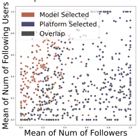

NOTE: figure/graphic rendered as an image from the PDF; its content is not machine-readable text. Caption (if any) follows as the next block.

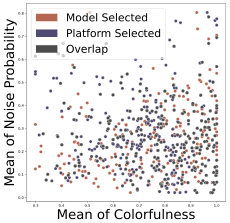

NOTE: figure/graphic rendered as an image from the PDF; its content is not machine-readable text. Caption (if any) follows as the next block.

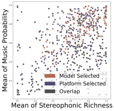

NOTE: figure/graphic rendered as an image from the PDF; its content is not machine-readable text. Caption (if any) follows as the next block.

**Cheng et al.:** *A Deep-DiD Method to Estimate Heterogeneous Treatment Effects* Marketing Science, 2026, vol. 45, no. 2, pp. 258–279, © 2026 INFORMS 275

Page 19

there exist complicated interactions between creator features in determining the HTE. These complicated and ex ante unknown interactions are hard, if not impossible, to capture using parametric functions (not to say linear functions), whereas the DNN has supe rior performance in estimating such complicated non parametric relationships.

**6. Concluding Remarks** In this paper, we propose a Deep-DiD model that incorporates two DNN structures in a DiD framework to estimate HTEs. We conduct a series of simulations showing that our approach can uncover the true values of HTEs with high accuracy. Furthermore, we apply our method to an empirical setting to estimate the HTEs of a “Creator Signing Program” launched by a large video-sharing platform and use the esti mated HTEs to optimize creator selection for the plat form. We show that compared with creators selected by the platform, creators selected by our model have not only higher estimated treatment effects but also higher actual performance jumps after being signed. Creator selection based on the Deep-DiD model also demonstrates consistently better performance than that based on linear models.

To the best of our knowledge, our paper represents the first implementation of the DNN-based heteroge neity architecture proposed by Farrell et al. (2020) in a real empirical context. We innovatively integrate two DNN structures with the DiD framework, setting up a dual-network architecture to allow for flexible non parametric relationships between the HTEs and pre treatment features, as well as possible interactions between fixed effects. We demonstrate the perfor mance of this method through simulations.

Through the empirical application, we demonstrate the significant potential for managerial applications of our approach. Platforms or influencer agency compa nies can initiate a pilot signing program and utilize data from this program in conjunction with our Deep- DiD model to estimate the expected treatment effect of the signing program on individual creators’ perfor mance as a function of their pretreatment features. Then, they can automate the process of creator selec tion by targeting those with the highest estimated treatment effects.

The application of our method extends beyond this context. Our method can be easily tailored to other empirical settings, especially those with a rich data set, to estimate the HTEs of a certain treatment. Researchers can flexibly define the pretreatment fea tures and the outcome variable. We have demonstrated that our method can uncover the true distribution of HTEs with high accuracy under various settings, and

the estimated HTEs can help optimize the selection of individuals to be treated in the future.

A limitation of our method is that we cannot provide standard errors for the estimated treatment effects. It is still unknown whether the estimated individual-level heterogeneity has traditional consistency and asymp totic statistical properties (Farrell et al. 2020). Our focus is not on the statistical significance of treatment effects but on how they vary with individuals’ pretreatment features, which enables targeting or selection based on pretreatment features, such as the creator selection application demonstrated in this paper or customer tar geting for profit-maximizing (see, e.g., Simester et al. 2020 and Hitsch et al. 2024). Statistical inference is pos sible for functions of the estimated individual-level heterogeneity under certain conditions (Chernozhukov et al. 2018, Farrell et al. 2020), and thus, it is possible to derive standard errors for profits of targeting policies (Zhang 2024). This can be a future research direction.

**Acknowledgments** The authors received helpful comments from conference attendees of the ISMS Marketing Science Conference, Hong Kong Quantitative Marketing Workshop, HKUST-USC Digital Transformation Conference, China India Insights Conference, Tsinghua SEM Alumni Forum, Marketing and the Creator Economy Conference, POMS-HK International Conference, INFORMS Annual Meeting, and seminar atten dees at Tongji University, Shanghai University of Finance and Economics, and the Chinese University of Hong Kong. The authors thank the Senior Editor, the Associate Editor, and the anonymous reviewers for their constructive com ments and helpful suggestions, which have greatly improved this paper. Yuhui Zhang was an employee of the company that provided the proprietary data set used in this paper. The first three authors contributed equally and are listed in reverse order of seniority.

#### **Endnotes**

**1** To protect the platform’s identity, we do not reveal the exact coun tries. This platform was relatively new and did not have a large user base in these countries. Thus, instead of setting specific criteria and allowing eligible creators to apply, as YouTube and TikTok did, this platform handpicked a group of creators and offered them contracts.

**2** For creators in the control group, the signing date is defined as that of the creator in the treated group to whom they are matched.

**3** https://www.mckinsey.com/featured-insights/mckinseyexplainers/what-is-influencer-marketing.

**4** “Inference” here means to provide a point estimate as well as the standard errors of the estimate.

**5** In practice, we can first use the default embedding function in PyTorch to generate embeddings of the high-dimensional individ ual dummies and time-period dummies and use the embeddings as the input layer of this network. This method is equivalent to using the high-dimensional individual dummies and time-period dum mies as the input layer directly, but it reduces the dimension of the

**Cheng et al.:** *A Deep-DiD Method to Estimate Heterogeneous Treatment Effects* 276 Marketing Science, 2026, vol. 45, no. 2, pp. 258–279, © 2026 INFORMS

Page 20

input layer of the DNN and thus can conserve RAM and decrease computation time.

**6** We make these distribution parameter assumptions so that there is enough variation in β*i* and *Di*, and the model performance under different settings can be demonstrated clearly. We have tested that our model also works under different distribution parameter assumptions.

**8** We omit reporting *p* values for the Kolmogorov-Smirnov test for two reasons. First, there lacks a framework to quantify the theoreti cal variances or bounds of distributions estimated by neural net works with the current asymptotic theory, and therefore, the traditional statistical tests may not be applicable here. Second, our large sample sizes lead to consistent statistical significance, even for negligible differences. This is a well-known “large n problem” in hypothesis testing. Thus, we focus on the KS statistic and JS diver gence as more informative measures of distributional differences rather than conducting hypothesis tests.

**9** Note that the unobservable time-invariant confounder *µi* is unob servable to researchers but can be observable to the platform when deciding the treatment assignment.

**10** We choose not to test different numbers of layers or activation functions because the structure we use in simulations (two hidden layers) already represents a minimal configuration in DNN, and ReLU is a common and effective choice for many neural network architectures.

**11** Note that when estimating β(·) using a linear model (in Figure 5(a)), we still use our Deep-DiD framework but assume the HTE estimation network as single-layer, which is equivalent to assuming β(·) as a linear function. To isolate the effect of the linear estimator of β(·), the fixed-effect network is still assumed to be a multi-layer DNN, consistent with other simulations. We discuss the advantage of this implementation over traditional ordinary least squares (OLS) in the final paragraph of Section 5.2. Similarly, when estimating the fixed effects *f*(·,·) using a linear model (in Figure 5(b)), we use Deep-DiD framework with a single-layer, fixed-effect network, whereas the HTE estimation network remains a multilayer DNN as in other simulations.

**12** Random forests have been used to estimate heterogeneous treat ment effects (see, e.g., Cong et al. 2021 and Guo et al. 2021), but we have not found the inclusion of fixed effects in existing works.

**13** The platform collaborates with several local agency companies to conduct the selection, and different local agency companies may adopt slightly different selection criteria. Therefore, unfortunately, we do not have access to their detailed selection criteria or the exact list of creators selected. We can only observe who joined the pro gram. According to the platform manager, very few selected crea tors chose not to join the program because there was essentially no cost for them to do so and the contract was not exclusive. The monthly payment for a creator was determined based on a compre hensive evaluation of the creator’s performance, including the num ber of videos created, the total user watching time and interactions contributed by the videos, etc. The exact calculation formula for the payment is confidential.

**14** Because of data confidentiality, we cannot reveal the total num ber of creators signed in this time period.

**15** It is possible to match a group of unsigned creators with a subset of signed creators on their mean performance levels, but the sample size will be limited.

**16** Note that the conventional DiD model can address both timeinvariant (e.g., inherent abilities, family background) and time- variant unobservable confounders (e.g., platform popularity, economic shifts, policy changes). Time-varying confounders affecting all units equally or randomly are differenced out in the first-stage differenc ing (over time) in DiD. Time-invariant gaps between treatment and control groups are differenced out in the second-stage differencing (across units). We have also verified that our Deep-DiD model can address these two types of confounders through simulations, as shown in Figure 4. Time-varying confounders specific to the treated group posttreatment (e.g., positive feedback loop) cannot be differ enced out but are of interest to the platform and researchers as part of the overall treatment effect.

**17** This threshold is necessary because trends are poorly defined for creators with too few videos in the pretreatment period. Although five videos are not ideal, setting a higher threshold would severely limit our sample size.

**18** Our matching procedure shares a similar spirit with the synthetic DiD method proposed by Arkhangelsky et al. (2021). Both methods aim to construct a control group with a parallel pretreatment trend relative to the treated group based on the idea that DiD requires parallel trends rather than statistical indifference in pretreatment outcomes. We choose not to use the synthetic DiD method for matching because its computationally intensive weighting and reg ularization parameters would have overcomplicated the implemen tation of our Deep-DiD method. Note that this matching procedure is not central to our Deep-DiD method; its sole purpose is to con struct a control group from a very large pool of untreated units. In future applications, if the data set already has treated and control groups satisfying the parallel-trend condition, then our Deep-DiD method can be applied directly. If matching is needed, what match ing method and matching variables to use depends on the specific empirical context.

**19** We have access to data from February 1, 2022, onward. For crea tors signed on May 1, 2022, we have 89 days of pre-signing data (February 1 to April 30).

**20** The number of “follows” a video gets means how many users decide to follow the creator after watching the video.

**21** We do not know what measures the platform uses to evaluate the impact of this signing program, nor do we have access to the exact formula the platform uses to calculate each creator’s payment. Thus, we do not have a well-defined set of performance measures at hand and need to define the key performance measures by our selves based on our understanding of the primary goals of the platform.

**22** For *User Time Contributed*, we first calculate it for each video by aggregating the total watch time a video gets in the first 20 days fol lowing the video’s release, because based on historical data, usually a video gets most exposures in the first 20 days after release. Then, we aggregate it to the creator-day level by summing up the values of videos created by the creator on that day. The main reason for this handling is that the outcome variables are to capture the contri bution a creator made to the platform on a day by uploading videos. If a creator has no videos uploaded on a day, then the vari able value is 0 for this creator on that day. For *User Engagement*, we first follow the same procedure to aggregate each of the four inter action metrics (likes, comments, shares, and follows) from video- level to creator-day level and then conduct PCA. Factor loadings of the four components are reported in Online Appendix A.2.

**Cheng et al.:** *A Deep-DiD Method to Estimate Heterogeneous Treatment Effects* Marketing Science, 2026, vol. 45, no. 2, pp. 258–279, © 2026 INFORMS 277

Page 21

**23** A caveat here is that the TWFE estimators (Columns (2) and (4) in Table 4) can be biased, as discussed in Section 1.1.

**24** Winsorization means to replace outliers with the value of speci fied percentiles. Winsorization can be one-sided or two-sided. For example, a 5% winsorization on the upper side (or the right tail) means to replace all values higher than the 95th percentile value with the 95th percentile value.

**25** Note that the first step of data split is by creators, whereas the second step is by creator-day level observations.

**26** A random seed is a number that initializes a pseudorandom number generator that is typically used to determine initial weights and can also affect the optimization process. Randomness in the DNN training may arise from weight initialization and mini-batch sampling in the optimization process. Training a DNN model multi ple times with different random seeds and aggregating the results is a widely used practice known as *deep ensemble*, which has been shown to reduce variance, stabilize performance, and improve gen eralization (Lakshminarayanan et al. 2017, Fort et al. 2019, Bethard 2022). Practically, this approach is also more cost-effective than alternatives such as acquiring more data.

**27** Note that we have to constrain our comparison within the crea tors who were actually signed because for creators who were not signed, we cannot empirically observe their change in performance after being signed.

**References** Abadie A, Gardeazabal J (2003) The economic costs of conflict: A case

study of the basque country. *Amer. Econom. Rev.* 93(1):113–132. Abadie A, Diamond A, Hainmueller J (2010) Synthetic control meth

ods for comparative case studies: Estimating the effect of Cali fornia’s tobacco control program. *J. Amer. Stat. Assoc.* 105(490): 493–505. Aggarwal CC (2018) *Neural Networks and Deep Learning*, vol. 10, No.

978 (Springer, Cham, Switzerland). Arkhangelsky D, Athey S, Hirshberg DA, Imbens GW, Wager S

(2021) Synthetic difference-in-differences. *Amer. Econom. Rev.* 111(12):4088–4118. Ascarza E (2018) Retention futility: Targeting high-risk customers

might be ineffective. *J. Marketing Res.* 55(1):80–98. Athey S, Tibshirani J, Wager S (2019) Generalized random forests.

*Ann. Statist.* 47(2):1148–1178. Belloni A, Chernozhukov V, Fern´andez-Val I, Hansen C (2017) Pro

gram evaluation and causal inference with high-dimensional data. *Econometrica* 85(1):233–298. Bengio Y (2012) Practical recommendations for gradient-based train

ing of deep architectures. Montavon G, Orr GB, M¨uller K-R, eds. *Neural Networks: Tricks of the Trade*, 2nd ed. (Springer, Ber lin, Heidelberg), 437–478. Bertrand M, Duflo E, Mullainathan S (2004) How much should we

trust differences-in-differences estimates? *Quart. J. Econom.* 119(1):249–275. Bethard S (2022) We need to talk about random seeds. Preprint, sub

mitted October 24, https://arxiv.org/abs/2210.13393. Bhargava HK (2022) The creator economy: Managing ecosystem

supply, revenue sharing, and platform design. *Management Sci.* 68(7):5233–5251. Borusyak K, Jaravel X, Spiess J (2024) Revisiting event-study

designs: Robust and efficient estimation. *Rev. Econom. Stud.* 91(6):3253–3285. Brodie RJ, Hollebeek LD, Juri´c B, Ili´c A (2011) Customer engagement:

Conceptual domain, fundamental propositions, and implications for research. *J. Service Res.* 14(3):252–271. Burtch G, Hong Y, Bapna R, Griskevicius V (2018) Stimulating

online reviews by combining financial incentives and social norms. *Management Sci.* 64(5):2065–2082.

Callaway B, Sant’Anna PH (2021) Difference-in-differences with

multiple time periods. *J. Econom.* 225(2):200–230. Cao J, Li X, Zhang L (2025) Is relevancy everything? A deep-learn

ing approach to understand the effect of image-text congruence. *Management Sci.* 71(12):10579–10602. Chaisemartin Cd, D’Haultfœuille X (2020) Two-way fixed effects

estimators with heterogeneous treatment effects. *Amer. Econom. Rev.* 110(9):2964–2996. Cheng MM, Zhang S (2024) Reputation burning: Analyzing the

impact of brand sponsorship on social influencers. *Management Sci.* 71(7):5910–5932. Chernozhukov V, Chetverikov D, Demirer M, Duflo E, Hansen C,

Newey W, Robins J (2018) Double/debiased machine learning for treatment and structural parameters. *Econometrics J.* 21(1):C1–C68. Cong Z, Liu J, Manchanda P (2021) The role of “live” in livestream

ing markets: Evidence using orthogonal random forest. Pre print, submitted July 4, https://arxiv.org/abs/2107.01629. Dew R, Ansari A, Toubia O (2022) Letting logos speak: Leveraging

multiview representation learning for data-driven branding and logo design. *Marketing Sci.* 41(2):401–425. Duflo E (2003) Grandmothers and granddaughters: Old-age pen

sions and intrahousehold allocation in South Africa. *World Bank Econom. Rev.* 17(1):1–25. Dzyabura D, El Kihal S, Hauser JR, Ibragimov M (2023) Leveraging

the power of images in managing product return rates. *Market ing Sci.* 42(6):1125–1142. Farrell MH, Liang T, Misra S (2020) Deep learning for individual

heterogeneity: An automatic inference framework. Preprint, submitted October 28, https://arxiv.org/abs/2010.14694. Farrell MH, Liang T, Misra S (2021) Deep neural networks for esti

mation and inference. *Econometrica* 89(1):181–213. Feng XF, Zhang S, Liu X, Srinivasan K, Lamberton CP (2025) An AI

method to score celebrity visual potential. *J. Marketing Res.* 62(5):757–775 Fong NM, Fang Z, Luo X (2015) Geo-conquesting: Competitive loca

tional targeting of mobile promotions. *J. Marketing Res.* 52(5): 726–735. Fong H, Kumar V, Sudhir K (2022) A theory-based explainable

deep learning architecture for music emotion. Preprint, submit ted February 9, http://dx.doi.org/10.2139/ssrn.4025386. Fort S, Hu H, Lakshminarayanan B (2019) Deep ensembles: A loss

landscape perspective. Preprint, submitted December 5, https:// arxiv.org/abs/1912.02757. Goodfellow I, Bengio Y, Courville A (2016) *Deep Learning* (MIT Press,

Cambridge, MA). Guo T, Sriram S, Manchanda P (2021) The effect of information dis

closure on industry payments to physicians. *J. Marketing Res.* 58(1):115–140. Hill JL (2011) Bayesian nonparametric modeling for causal inference.

*J. Comput. Graph. Statist.* 20(1):217–240. Hitsch GJ, Misra S, Zhang WW (2024) Heterogeneous treatment

effects and optimal targeting policy evaluation. *Quant. Market ing Econom.* 22(2):115–168. Huang Y, Morozov I (2025) The promotional effects of live streams

by twitch influencers. *Marketing Sci.* 44(4):916–932. Huang N, Burtch G, Gu B, Hong Y, Liang C, Wang K, Fu D, Yang

B (2019) Motivating user-generated content with performance feedback: Evidence from randomized field experiments. *Man agement Sci.* 65(1):327–345. Hwang S, Liu X, Srinivasan K (2021) Voice analytics of online influ

encers. Preprint, submitted February 18, http://dx.doi.org/10. 2139/ssrn.3773825. Jain S, Qian K (2021) Compensating online content producers: A

theoretical analysis. *Management Sci.* 67(11):7075–7090. Lakshminarayanan B, Pritzel A, Blundell C (2017) Simple and scal

able predictive uncertainty estimation using deep ensembles. Guyon I, Luxburg UV, Bengio S, Wallach H, Fergus R,

**Cheng et al.:** *A Deep-DiD Method to Estimate Heterogeneous Treatment Effects* 278 Marketing Science, 2026, vol. 45, no. 2, pp. 258–279, © 2026 INFORMS

Page 22

Vishwanathan S, Garnett R, eds. *Proc. 31st Internat. Conf. Neural Inform. Processing Systems* (Curran Associates, Inc., Red Hook, NY), 6405–6416. Leung FF, Gu FF, Li Y, Zhang JZ, Palmatier RW (2022) Influencer

marketing effectiveness. *J. Marketing* 86(6):93–115. Li Y, Xie Y (2020) Is a picture worth a thousand words? An empiri

cal study of image content and social media engagement. *J. Marketing Res.* 57(1):1–19. Li KT, Luo L, Pattabhiramaiah A (2024) Causal inference with

quasi-experimental data. *IMPACT at JMR*. https://www.ama. org/marketingnews/causal-inference-with-quasi-experimental- data. Li X, Shi M, Wang XS (2019) Video mining: Measuring visual infor

mation using automatic methods. *Internat. J. Res. Marketing* 36(2):216–231. Liu X (2023) Deep learning in marketing: A review and research

agenda. *Artificial Intelligence Marketing* (Emerald Publishing Limited, Bingley, UK), 239–271. Liu L, Dzyabura D, Mizik N (2020) Visual listening in: Extracting

brand image portrayed on social media. *Marketing Sci.* 39(4): 669–686. Liu X, Lee D, Srinivasan K (2019) Large-scale cross-category analysis

of consumer review content on sales conversion leveraging deep learning. *J. Marketing Res.* 56(6):918–943. Liu Z, Zhang W, Liu X, Muller E, Xiong F (2022) Success and sur

vival in livestream shopping. Preprint, submitted February 9, http://dx.doi.org/10.2139/ssrn.4028092. Lu S, Xie Y, Chen X (2023) Immediate and enduring effects of digi

tal badges on online content consumption and generation. *Inter nat. J. Res. Marketing* 40(1):146–163. Lu S, Yao D, Chen X, Grewal R (2021) Do larger audiences generate

greater revenues under pay what you want? Evidence from a live streaming platform. *Marketing Sci.* 40(5):964–984. Oestreicher-Singer G, Zalmanson L (2013) Content or community?

A digital business strategy for content providers in the social age. *MIS Quart.* 37(2):591–616. Oprescu M, Syrgkanis V, Wu ZS (2019) Orthogonal random forest

for causal inference. *Internat. Conf. Machine Learn.* (PMLR), 4932–4941. Rajaram P, Manchanda P (2021) Unboxing engagement in YouTube

influencer videos: An attention-based approach. Preprint, sub mitted January 25, http://dx.doi.org/10.2139/ssrn.3752107.

Roth J, Sant’Anna PH, Bilinski A, Poe J (2023) What’s trending in

difference-in-differences? A synthesis of the recent econometrics literature. *J. Econom.* 235(2):2218–2244. Simester D, Timoshenko A, Zoumpoulis SI (2020) Targeting pro

spective customers: Robustness of machine-learning methods to typical data challenges. *Management Sci.* 66(6):2495–2522. Sun L, Abraham S (2021) Estimating dynamic treatment effects in

event studies with heterogeneous treatment effects. *J. Econom.* 225(2):175–199. Tian Z, Dew R, Iyengar R (2024) Mega or micro? Influencer selec

tion using follower elasticity. *J. Marketing Res.* 61(3):472–495. Wager S, Athey S (2018) Estimation and inference of heterogeneous

treatment effects using random forests. *J. Amer. Statist. Assoc.* 113(523):1228–1242. Wang X, Lu S, Li X, Khamitov M, Bendle N (2021) Audio mining: The

role of vocal tone in persuasion. *J. Consumer Res.* 48(2):189–211. Wei Y, Jiang Z (2022) Estimating parameters of structural models

using neural networks. USC Marshall School of Business Research Paper. Wies S, Bleier A, Edeling A (2023) Finding goldilocks influencers:

How follower count drives social media engagement. *J. Market ing* 87(3):383–405. Yang M, Ren Y, Adomavicius G (2019) Understanding user-

generated content and customer engagement on facebook busi ness pages. *Inform. Systems Res.* 30(3):839–855. Yang J, Zhang J, Zhang Y (2025) Engagement that sells: Influencer

video advertising on TikTok. *Marketing Sci.* 44(2):247–267. Zeng Z, Dai H, Zhang DJ, Zhang H, Zhang R, Xu Z, Shen Z-JM

(2022) The impact of social nudges on user-generated content for social network platforms. *Management Sci.* 69(9):5189–5208. Zhang WW (2024) Optimal comprehensible targeting. PhD thesis,

University of Chicago Booth School of Business, Chicago. Zhang M, Luo L (2023) Can consumer-posted photos serve as a

leading indicator of restaurant survival? Evidence from Yelp. *Management Sci.* 69(1):25–50. Zhang S, Lee D, Singh PV, Srinivasan K (2022) What makes a good

image? Airbnb demand analytics leveraging interpretable image features. *Management Sci.* 68(8):5644–5666. Zhou M, Chen GH, Ferreira P, Smith MD (2021) Consumer behavior

in the online classroom: Using video analytics and machine learning to understand the consumption of video courseware. *J. Marketing Res.* 58(6):1079–1100.

**Cheng et al.:** *A Deep-DiD Method to Estimate Heterogeneous Treatment Effects* Marketing Science, 2026, vol. 45, no. 2, pp. 258–279, © 2026 INFORMS 279

Page 23